# Raport Python

Author

Adam & Yasmine

## Partie 1

## 1. Chargement des données avec Pandas et aperçu

Dans cette première étape, nous allons charger les données du fichier CSV.

Nous visualiserons un aperçu des données pour vérifier le bon chargement

```
Salle 1 :
  regionCNC : 1
  fauteuils : 589
  entrees_2022 : 101443
  entrees_2021 : 55067
  latitude : 48.872431
  longitude : 2.299525
  geolocalisation : 48.872431, 2.299525
  num_auto : 35
  region_administrative : ILE-DE-FRANCE
  code_INSEE : 75108
  population_de_la_commune : 36218
  departement : 75
  num_UU : 851
  unite_urbaine : Paris
  population_unite_urbaine : 10949158
  situation_geographique : 01-Paris
  ecrans : 3
  semaines_d_activite : 51
  seances : 4602
  evolution_entrees : 84,21740788
  tranche_d_entrees : De 100 à 150 000 entrées
  categorie_Art_et_Essai : A
  label_Art_et_Essai : RD
  zone_de_la_commune : C
  nombre_de_films_programmes : 203
  nombre_de_films_inedits : 80
  nombre_de_films_en_semaine_1 : 59
  PdM_en_entrees_des_films_francais : 70,18649803
  PdM_en_entrees_des_films_americains : 2,681664384
  PdM_en_entrees_des_films_europeens : 15,67006364
  PdM_en_entrees_des_autres_films : 11,46177395
  films_Art_et_Essai : 145
  PdM_en_entrees_des_films_Art_et_Essai : 89,68319504
------------------------------
```

Il est aussi possible de sélectionner certaines données, c’est-à-dire de choisir uniquement quelques variables pertinentes.

Voici un exemple :

```python
data = selectionne_variable(donnees, ["fauteuils","entrees_2022","entrees_2021", "ecrans", "seances" ])
```

## 2. Nettoyage / Gestion des données

Nous avons d’abord créé une variable de type dictionnaire qui stocke les anciens noms et leurs correspondances avec les nouveaux noms dans les données.

Voici des exemple :

rennomer_variable (donnees, nouvelles_var)

rennomer_variable (donnees2021, nouvelles_var)

rennomer_variable (donnees2020, nouvelles_var)

rennomer_variable (donnees2019, nouvelles_var)

rennomer_variable (donnees2018, nouvelles_var)

## 3. Analyse, visualisation d’un seul jeu de données (tableaux et graphiques)

```
fauteuils:
  count   = 2061
  mean    = 563.48
  min     = 18.0
  max     = 7358.0
  median  = 289.0
  écart-type = 710.83
  nombre valeurs manquantes = 0

entrees_2022:
  count   = 2061
  mean    = 73993.13
  min     = 1.0
  max     = 2221205.0
  median  = 20201.0
  écart-type = 140956.58
  nombre valeurs manquantes = 0

entrees_2021:
  count   = 2023
  mean    = 46141.46
  min     = 22.0
  max     = 1408789.0
  median  = 11800.0
  écart-type = 89975.95
  nombre valeurs manquantes = 38

ecrans:
  count   = 2061
  mean    = 3.06
  min     = 1.0
  max     = 27.0
  median  = 1.0
  écart-type = 3.55
  nombre valeurs manquantes = 0

seances:
  count   = 2061
  mean    = 4083.56
  min     = 1.0
  max     = 61489.0
  median  = 1041.0
  écart-type = 6527.13
  nombre valeurs manquantes = 0

None
```

Dans cette étape, nous effectuons un **traitement statistique descriptif** sur le jeu de données de l’année 2022. L’objectif est de résumer les principales caractéristiques des variables numériques présentes dans le tableau.

`describe()`est une fonction en Python. Elle permet d’obtenir un **résumé statistique** des colonnes **numériques**

### Observations principales :

- **Fauteuils** :  
  Moyenne de 563 places par cinéma, mais une forte disparité (min : 18, max : 7358), avec un écart-type élevé (710,83), indiquant une hétérogénéité importante entre les établissements.
- **Entrées 2022** :  
  Moyenne de près de 74 000 entrées par cinéma. Cependant, la médiane (20 201) bien inférieure à la moyenne et l’écart-type élevé (140 956) révèlent la présence de cinémas à très forte fréquentation.
- **Entrées 2021** :  
  Moyenne plus faible (46 141) avec une médiane à 11 800, ce qui reflète l’impact probable de la pandémie. 38 valeurs manquantes sont à noter.
- **Écrans** :  
  Les cinémas ont en moyenne 3 écrans, mais la médiane (1) suggère que la majorité n’en possède qu’un seul. L’écart-type (3,55) confirme une forte variabilité.
- **Séances** :  
  Moyenne de 4 084 séances par an, mais une distribution très déséquilibrée (médiane : 1041, max : 61 489), avec un écart-type élevé (6527), témoignant d’importantes différences d’activité.

## Analyse du matériel par département

Pour analyser la répartition du matériel, nous avons créé les codes Python suivants.

La fonction `tableau_nb_cinema_par_dep` **compte le nombre de cinémas par département** à partir d’une liste de données.

Cette fonction `tableau_repartion_materiels` calcule la répartition du nombre d’écrans et de fauteuils par département à partir d’une liste de données.

Cette fonction `ratio_fauteuils_par_commune` calcule, pour chaque commune, le ratio entre le nombre de fauteuils de cinéma et la population, à partir des codes INSEE.

La fonction **`ratio_fauteuils_par_commune`** calcule, pour chaque commune, le ratio entre le nombre total de fauteuils de cinéma et la population municipale.

## Analyse des programmes par département

Pour analyser la répartition des programmes, nous avons créé les codes Python suivants.

Cette fonction `tableau_repartion_programmation` calcule, pour chaque département, la répartition moyenne de la programmation cinématographique en agrégeant les séances, les semaines d’activité, le nombre de films et les parts de marché des films français et américains.

## Analyse de la fréquentation des cinémas

Pour analyser la répartition de la fréquentation , nous avons créé les codes Python suivants.

Cette fonction `tableau_repartion_frequentation` calcule, pour chaque département, le total des entrées en 2022 et des semaines d’activité à partir d’une liste de données sur la fréquentation cinématographique.

La fonction **`nb_cine_par_tranche`** calcule, à partir d’une liste de données, le nombre de cinémas présents pour chaque tranche d’entrées.

La fonction **`tableau_frequence`** calcule la fréquence relative du nombre de séances de cinéma pour chaque département, en comparant leur poids par rapport au total national.

## Analyse de l’évolution selon une modalité

La fonction **`evolution_par_annee`** calcule l’évolution annuelle d’une **modalité numérique** (comme le nombre de fauteuils ou de séances) pour chaque département, à partir des données de cinq années consécutives (2018 à 2022).

## 4 . Export

Ta fonction **`exporterdict(datadict, file)`** sert à **exporter des données structurées sous forme de dictionnaires** vers un fichier CSV.

**Enfin, une fonction appelée *menu général* permet de manipuler et d’accéder à toutes ces fonctionnalités.**

## Partie 2

## 1. Chargement des données avec Pandas et aperçu

Dans cette première étape, nous allons charger les données du fichier CSV avec la bibliothèque **pandas**.

Nous visualiserons un aperçu des données pour vérifier le bon chargement

|  | régionCNC | N° auto | nom | région administrative | adresse | code INSEE | commune | population de la commune | DEP | N°UU | ... | nombre de films en semaine 1 | PdM en entrées des films français | PdM en entrées des films américains | PdM en entrées des films européens | PdM en entrées des autres films | films Art et Essai | PdM en entrées des films Art et Essai | latitude | longitude | geolocalisation |
| --- | --- | --- | --- | --- | --- | --- | --- | --- | --- | --- | --- | --- | --- | --- | --- | --- | --- | --- | --- | --- | --- |
| 0 | 1 | 35 | BALZAC | ILE-DE-FRANCE | 1 RUE BALZAC | 75108 | Paris 8e Arrondissement | 36218 | 75 | 00851 | ... | 59 | 70,18649803 | 2,681664384 | 15,67006364 | 11,46177395 | 145 | 89,68319504 | 48.872431 | 2.299525 | 48.872431, 2.299525 |
| 1 | 1 | 301 | MAX LINDER | ILE-DE-FRANCE | 24 BD POISSONNIERE | 75109 | Paris 9e Arrondissement | 60784 | 75 | 00851 | ... | 18 | 20,39299799 | 40,96588943 | 29,4457898 | 9,19532277 | 81 | 55,16916903 | 48.871363 | 2.344886 | 48.871363, 2.344886 |
| 2 | 1 | 483 | ENTREPOT | ILE-DE-FRANCE | 7 ET 9 RUE FRANCIS DE PRESSENSE | 75114 | Paris 14e Arrondissement | 134926 | 75 | 00851 | ... | 14 | 62,23226656 | 10,35500943 | 19,6084221 | 7,804301906 | 302 | 89,05217253 | 48.833930 | 2.316520 | 48.83393, 2.31652 |
| 3 | 1 | 612 | UGC CINE CITE MAILLOT | ILE-DE-FRANCE | PALAIS CONGRES PL PORTE MAILLOT | 75117 | Paris 17e Arrondissement | 167765 | 75 | 00851 | ... | 153 | 59,91891175 | 23,96282137 | 10,86842358 | 5,249843301 | 148 | 36,87652111 | 48.878512 | 2.282965 | 48.878512, 2.282965 |

4 rows × 40 columns

## 2. Nettoyage / Gestion des données

|  | régionCNC | num_auto | nom | region_administrative | adresse | code_INSEE | commune | population_de_la_commune | departement | num_UU | ... | nombre_de_films_en_semaine_1 | PdM_en_entrees_des_films_francais | PdM_en_entrees_des_films_americains | PdM_en_entrees_des_films_europeens | PdM_en_entrees_des_autres_films | films_Art_et_Essai | PdM_en_entrees_des_films_Art_et_Essai | latitude | longitude | geolocalisation |
| --- | --- | --- | --- | --- | --- | --- | --- | --- | --- | --- | --- | --- | --- | --- | --- | --- | --- | --- | --- | --- | --- |
| 0 | 1 | 35 | BALZAC | ILE-DE-FRANCE | 1 RUE BALZAC | 75108 | Paris 8e Arrondissement | 36218 | 75 | 00851 | ... | 59 | 70,18649803 | 2,681664384 | 15,67006364 | 11,46177395 | 145 | 89,68319504 | 48.872431 | 2.299525 | 48.872431, 2.299525 |
| 1 | 1 | 301 | MAX LINDER | ILE-DE-FRANCE | 24 BD POISSONNIERE | 75109 | Paris 9e Arrondissement | 60784 | 75 | 00851 | ... | 18 | 20,39299799 | 40,96588943 | 29,4457898 | 9,19532277 | 81 | 55,16916903 | 48.871363 | 2.344886 | 48.871363, 2.344886 |
| 2 | 1 | 483 | ENTREPOT | ILE-DE-FRANCE | 7 ET 9 RUE FRANCIS DE PRESSENSE | 75114 | Paris 14e Arrondissement | 134926 | 75 | 00851 | ... | 14 | 62,23226656 | 10,35500943 | 19,6084221 | 7,804301906 | 302 | 89,05217253 | 48.833930 | 2.316520 | 48.83393, 2.31652 |
| 3 | 1 | 612 | UGC CINE CITE MAILLOT | ILE-DE-FRANCE | PALAIS CONGRES PL PORTE MAILLOT | 75117 | Paris 17e Arrondissement | 167765 | 75 | 00851 | ... | 153 | 59,91891175 | 23,96282137 | 10,86842358 | 5,249843301 | 148 | 36,87652111 | 48.878512 | 2.282965 | 48.878512, 2.282965 |
| 4 | 1 | 751 | ST ANDRE DES ARTS | ILE-DE-FRANCE | 30 RUE ST ANDRE DES ARTS | 75106 | Paris 6e Arrondissement | 40452 | 75 | 00851 | ... | 61 | 73,87181094 | 7,770408935 | 12,52079238 | 5,836987751 | 181 | 81,03086993 | 48.853361 | 2.342110 | 48.853361, 2.34211 |

5 rows × 40 columns

Afin de pouvoir travailler efficacement sur notre jeu de données, il est indispensable de le nettoyer. Ce processus de nettoyage permet d’assurer la fiabilité et la cohérence des résultats obtenus lors de l’analyse. Il consiste à corriger les erreurs, traiter les valeurs manquantes, uniformiser les formats et supprimer les doublons. Ce travail préliminaire est essentiel pour garantir la qualité des conclusions que l’on pourra tirer par la suite.

## 3. Analyse, visualisation d’un seul jeu de données (tableaux et graphiques)

Dans cette étape, nous effectuons un **traitement statistique descriptif** sur le jeu de données de l’année 2022. L’objectif est de résumer les principales caractéristiques des variables numériques présentes dans le tableau.

L’instruction `data2022.describe()` est une commande de la bibliothèque **pandas** en Python. Elle permet d’obtenir un **résumé statistique** des colonnes **numériques** d’un DataFrame nommé ici `data2022`.

|  | régionCNC | N° auto | population de la commune | population unité urbaine | écrans | fauteuils | semaines d'activité | séances | entrées 2022 | entrées 2021 | nombre de films programmés | nombre de films inédits | nombre de films en semaine 1 | films Art et Essai | latitude | longitude |
| --- | --- | --- | --- | --- | --- | --- | --- | --- | --- | --- | --- | --- | --- | --- | --- | --- |
| count | 2061.000000 | 2061.000000 | 2061.000000 | 2.061000e+03 | 2061.000000 | 2061.000000 | 2061.000000 | 2061.000000 | 2.061000e+03 | 2.023000e+03 | 2061.000000 | 2061.000000 | 2061.000000 | 2061.000000 | 2061.000000 | 2061.000000 |
| mean | 4.521106 | 248574.161572 | 41105.630762 | 3.616797e+06 | 3.055798 | 563.478409 | 47.890830 | 4083.557982 | 7.399313e+04 | 4.614146e+04 | 210.057254 | 153.461912 | 55.057739 | 108.726832 | 46.616197 | 2.622983 |
| std | 1.983712 | 172494.828293 | 100057.953167 | 5.691535e+06 | 3.547773 | 710.825868 | 10.034321 | 6527.129857 | 1.409566e+05 | 8.997595e+04 | 101.149330 | 71.677271 | 70.372511 | 77.014118 | 2.242507 | 2.884411 |
| min | 1.000000 | 31.000000 | 0.000000 | 1.913000e+03 | 1.000000 | 18.000000 | 1.000000 | 1.000000 | 1.000000e+00 | 2.200000e+01 | 0.000000 | 0.000000 | 0.000000 | 0.000000 | 41.671492 | -4.723462 |
| 25% | 3.000000 | 104933.000000 | 4025.000000 | 1.023900e+04 | 1.000000 | 189.000000 | 48.000000 | 407.000000 | 8.470000e+03 | 4.665500e+03 | 142.000000 | 106.000000 | 1.000000 | 49.000000 | 44.677139 | 0.483469 |
| 50% | 4.000000 | 238886.000000 | 10060.000000 | 1.011940e+05 | 1.000000 | 289.000000 | 52.000000 | 1041.000000 | 2.020100e+04 | 1.180000e+04 | 206.000000 | 157.000000 | 18.000000 | 98.000000 | 46.790178 | 2.414699 |
| 75% | 6.000000 | 362414.000000 | 33046.000000 | 1.094916e+07 | 3.000000 | 553.000000 | 53.000000 | 4503.000000 | 6.767900e+04 | 4.162700e+04 | 271.000000 | 202.000000 | 98.000000 | 151.000000 | 48.763489 | 4.955836 |
| max | 9.000000 | 725480.000000 | 876602.000000 | 1.490853e+07 | 27.000000 | 7358.000000 | 53.000000 | 61489.000000 | 2.221205e+06 | 1.408789e+06 | 705.000000 | 458.000000 | 403.000000 | 512.000000 | 51.070372 | 9.531370 |

**Répartition du nombre de fauteuils et du nombre d’écrans selon le département.**

|  | DEP | Nombre d'ecran | Nombre de fauteuil |
| --- | --- | --- | --- |
| 0 | 01 | 41 | 7422 |
| 1 | 02 | 43 | 6894 |
| 2 | 03 | 26 | 4041 |
| 3 | 04 | 28 | 4878 |
| 4 | 05 | 34 | 4974 |

Cette fonction a pour objectif de **résumer, par département**, la répartition des équipements et du nombre de cinémas présents dans les données `data2022`.

#### Départements les mieux équipés :

- **Paris (75)**, les **Hauts-de-Seine (92)**, la **Seine-Saint-Denis (93)** et le **Val-de-Marne (94)** figurent parmi les départements les mieux dotés :

```
-    Par exemple, le département 92 dispose de 130 écrans et de 27 435 fauteuils, ce qui indique une offre cinématographique dense et une forte capacité d’accueil.

-   Ces départements urbains bénéficient d’une population élevée et d’une forte concentration d’infrastructures culturelles.
```

#### Départements moins équipés :

- Certains départements ruraux ou montagneux (comme le **03**, **04**, **05**) ont un **nombre réduit d’écrans et de fauteuils** :

```
-    Par exemple, le 03 (Allier) compte seulement 26 écrans pour 4041 fauteuils, ce qui reflète une offre plus limitée.

-    Cela peut s’expliquer par une densité de population plus faible et des besoins moindres en infrastructures.
```

#### Graphique interresant :

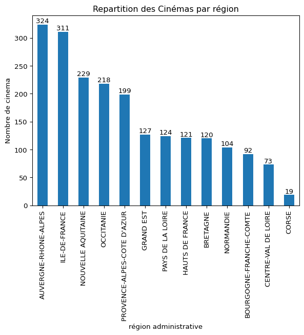

Ce graphique présente le nombre de **cinémas par région administrative** en France.

### Observations principales :

- L’Auvergne-Rhône-Alpes est la région comptant le plus de cinémas (324), suivie par l’Île-de-France (311) et la Nouvelle-Aquitaine (229).
- La Corse enregistre le plus faible nombre de cinémas (19).
- On observe une nette disparité régionale, probablement liée à la densité de population, à l’équipement culturel et à l’accessibilité géographique.

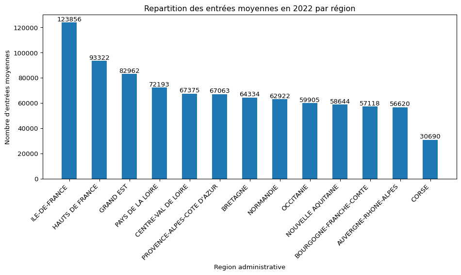

Ce graphique est un **diagramme en barres** représentant la **repartition des entrées moyennes en 2022 par région** en France.

### Observations principales :

- **L’Île-de-France** est de loin la région avec le plus grand nombre d’entrées moyennes (123 856), suivie par les **Hauts-de-France** (93 322) et le **Grand Est** (82 962).
- La **Corse** enregistre la plus faible moyenne (30 690).
- On remarque une **forte disparité régionale**, reflétant probablement la densité de population, l’offre cinématographique et les habitudes culturelles

Comparaison entre les deux graphique :

Le nombre de cinémas n’est pas forcément lié à leur fréquentation moyenne : certaines régions ont peu de cinémas mais une forte fréquentation (ex. : Hauts-de-France).

L’Île-de-France domine largement en quantité et fréquentation.

Auvergne-Rhône-Alpes, malgré un grand parc de cinémas, a une fréquentation faible par cinéma, ce qui peut indiquer une dispersion du public ou un réseau moins concentré.

La Corse reste en queue de peloton sur les deux aspects.

# 3. Chargement des autres jeux de données

Nous chargeons maintenant les autres données des années 2018 à 2021, afin de préparer les analyses multi-annuelles.

# 4. Agrégation des données, indicateurs et statistiques sur plusieurs années (tableaux ) + Export

Enfin, nous calculons l’évolution annuelle du nombre de fauteuils par département sur toutes les années. Les résultats seront présentés sous forme de tableau puis exportés.

|  | index | fauteuils_2018 | fauteuils_2019 | fauteuils_2020 | fauteuils_2021 | fauteuils_2022 |
| --- | --- | --- | --- | --- | --- | --- |
| 0 | 1 | 7038.0 | 7417.0 | 7422.0 | 7422.0 | NaN |
| 1 | 10 | 3803.0 | 3717.0 | 3717.0 | 3717.0 | 4214.0 |
| 2 | 11 | 5392.0 | 5698.0 | 5698.0 | 5624.0 | 5624.0 |
| 3 | 12 | 4783.0 | 4783.0 | 5801.0 | 5772.0 | 5854.0 |
| 4 | 13 | 30425.0 | 31978.0 | 31402.0 | 33753.0 | 32947.0 |

```
Fichier exporté : C:/Users/Adam/Downloads/Sae Mousaoui-Adam-Bououden-Yasmine/APPLICATION/data/EXPORT/STATISTIQUES//evolution_fauteuil.csv
```

**Il est possible d’exporter un tableau (DataFrame) avec Pandas en utilisant la méthode `.to_csv()`**, qui permet d’enregistrer les données au format CSV.

# 4. Conclusion

Au terme de ce projet, nous avons conçu une application Python permettant de manipuler et d’analyser des données sur plus de **2 000 établissements cinématographiques** en France, répartis sur l’ensemble des **101 départements**. L’objectif était de proposer une interface simple et fonctionnelle pour accéder rapidement à des statistiques structurées.

Grâce à la fonction de menu général, l’utilisateur peut visualiser les données, explorer les répartitions territoriales, produire des indicateurs avancés, et exporter les résultats au format `.csv` pour réutilisation.